# Assignment 1 - Exploratory Data analysis

Your-name-here

2023-02-12

## Set up

```r
ache <- read.csv("ache-hunting.csv")

library(tidyverse)
library(table1)
```

## 1. Getting familiar with the data

Start by taking a look at the structure of the dataframe and the first few rows. The `datatype` column is coded as follows: 1 if the duration of the trip was known; and 3 if the duration of the trip was not know.

#### Q1.1. What is the unit of observation for this dataframe? What variables are recorded about the unit of observation? **(2pt)**

One Ache person, specifically one Ache hunting trip.

Variables: month, day and year of the observation, id for the man, age of the man, amount of meat produced by the hunt, duration of the hunt, and “datatype”

```r
str(ache)
```

```
## 'data.frame':    14364 obs. of  9 variables:
##  $ X       : int  1 2 3 4 5 6 7 8 9 10 ...
##  $ month   : int  10 10 10 10 10 10 10 2 2 2 ...
##  $ day     : int  2 3 4 5 6 7 8 6 7 8 ...
##  $ year    : int  1981 1981 1981 1981 1981 1981 1981 1982 1982 1982 ...
##  $ id      : int  3043 3043 3043 3043 3043 3043 3043 3043 3043 3043 ...
##  $ age     : int  67 67 67 67 67 67 67 68 68 68 ...
##  $ kg.meat : num  0 0 0 4.5 0 0 0 0 0 0 ...
##  $ hours   : num  6.97 9 1.55 8 3 7.5 9 7.3 8.1 6 ...
##  $ datatype: num  1 1 1 1 1 1 1 1 1 1 ...
```

#### Q1.2. What are the vector and variable types for the following variables: `age`, `kg.meat`, `hours`, and `datatype`? **(4points)**

age: integer, numeric continuous or discrete kg.meat: double/numeric, numeric continuous hours: double/numeric, numeric continous datatype: numeric, categorical nominal

#### Q1.3. Are the vector types appropriate for each of the variable types? If not, coerce the variables to better-suited vector types.

Hint: To save a new variable in a dataframe, use the mutate function from the tidyverse exercise of week 1 or save a new variable using the following syntax: `dataframe$newvar <- function(dataframe$oldvar)`

**(1pt)**

```r
ache$datatype <- as.character(ache$datatype)
```

## 2. Summary statistics

Create a set of summary statistics for the following variables: `age`, `kg.meat`, `hours`, and `datatype` using the`table1` package.

#### Q2.1. Set informative labels for each of these variables **(1pt)**

```r
label(ache$age) <- "Age"
label(ache$kg.meat) <- "Meat return (in kg)"
label(ache$hours) <- "Hunt Duration"
label(ache$datatype) <- "Duration observed?"
```

#### Q2.2. Produce a table that summarizes these variables.

Hint: make sure that the output summaries make sense for the different types of variables. If not, consider adjusting the variable types, either by coercing them before using `table1` or by coercing them inside the `table1` function.

**(1pt)**

```r
table1(~ age + kg.meat + hours + datatype, data = ache)
```

|  | Overall (N=14364) |
| --- | --- |
| Age |  |
| Mean (SD) | 46.4 (13.6) |
| Median [Min, Max] | 47.0 [11.0, 75.0] |
| Meat return (in kg) |  |
| Mean (SD) | 3.21 (6.36) |
| Median [Min, Max] | 0 [0, 191] |
| Hunt Duration |  |
| Mean (SD) | 6.84 (2.19) |
| Median [Min, Max] | 7.10 [0.300, 14.0] |
| Missing | 12050 (83.9%) |
| Duration observed? |  |
| 1 | 2314 (16.1%) |
| 1.1 | 81 (0.6%) |
| 3 | 11969 (83.3%) |

#### Q2.4. Look at the summary statistics for `kg.meat`. Are the mean and median similar? What does this suggest about the distribution of the data? **(2pts)**

No, the mean and the median rae not similar. This suggests that the distribution of the data is skewed, specifically that there are a few very high values in the data set.

#### Q2.5. Create two separate count tables: one for year, and the other for month. Was the data collected evenly over the study period? Is there any seasonality in the observations i.e., does the data disproportionately cover certain months? **(3pts)**

```r
table(ache$year)
```

```
##
## 1980 1981 1982 1984 1985 1994 1995 1996 1997 1998 1999 2000 2001 2002 2003 2004
##  600  264  560   22  112   77  381 1023 1036 1556 1397 1730 1633  931  609  620
## 2005 2006 2007
##  902  792  119
```

```r
table(ache$month)
```

```
##
##    1    2    3    4    5    6    7    8    9   10   11   12
## 1304 1199 1105 1344 1108 1270 1433  999 1080 1408 1080 1034
```

## 3. Data visualization

#### Q3.1. Check your intuition about the distribution of the data for `kg.meat`. Consider the type and number of the variable(s) that you are trying to plot to select the correct visualization. Make sure you set a binwidth that makes sense in this context. **(1-pt)**

Hint: Consider that this variable measures the return of a hunt conducted by a single hunter, and that 1 kg = ~2lb.

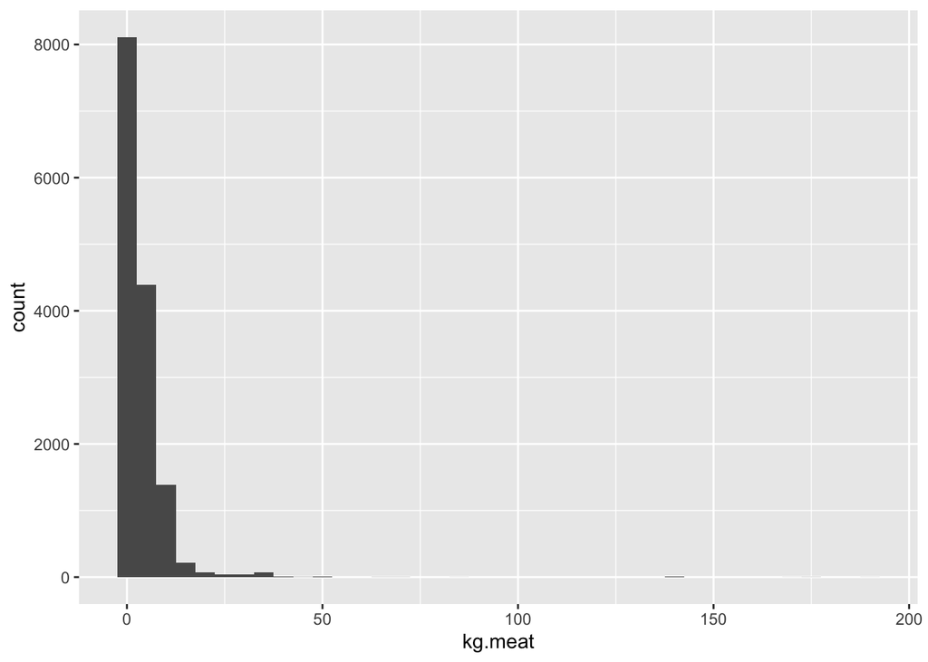

```r
ggplot(ache, aes(x = kg.meat))+
  geom_histogram(binwidth = 5)
```

#### Q3.2. Perhaps skill of the hunter increases the chance that a hunt will be successful, such that older hunters tend to return more meat? To explore this, make a plot that shows the relationship between the age of the hunter (x-axis) and the amount of meat returned by a hunt (y-axis). Then add both scattergram and smoothed linear regression line to the plot. Add an informative title and appropriate axes labels. **(2pts)**

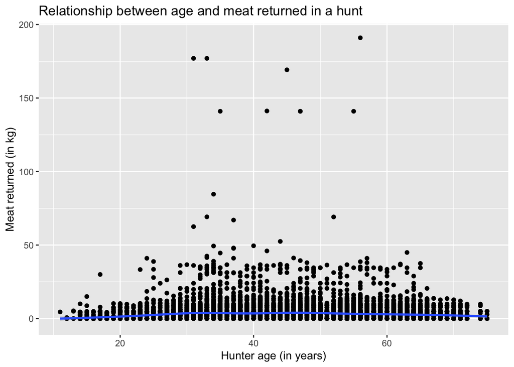

```r
ggplot(ache, aes(x = age, y = kg.meat))+
  geom_point()+
  geom_smooth()+
  labs(x = "Hunter age (in years)",
       y = "Meat returned (in kg)",
       title = "Relationship between age and meat returned in a hunt")
```

#### Q3.3. Using the plot you’ve just produced, do you think that there is a relationship between age of the hunter and the yield of the hunt? **(1pt)**

No, Because the smoothed line is very flat and the point cloud is very dispersed.